# ResearchProject-Anu-2

### Which factor affects the popularity of movie? Is it the budget or the length of movie?

```r
head(movielens_tmdb_combined_results)
```

| movieId | budget | popularity | release_date | revenue | runtime | vote_average | vote_count | Action | Adventure | ⋯ | Fantasy | Horror | IMAX | Musical | Mystery | Romance | Thriller | War | Western | MovielensRating |
| --- | --- | --- | --- | --- | --- | --- | --- | --- | --- | --- | --- | --- | --- | --- | --- | --- | --- | --- | --- | --- |
| 10 | 58000000 | 59.824565 | 1995-11-16 | 352194034 | 130 | 6.6 | 1174 | 1 | 1 | ⋯ | 0 | 0 | 0 | 0 | 0 | 0 | 1 | 0 | 0 | 3.430029 |
| 11 | 62000000 | 11.056763 | 1995-11-17 | 107879496 | 106 | 6.5 | 195 | 0 | 0 | ⋯ | 0 | 0 | 0 | 0 | 0 | 1 | 0 | 0 | 0 | 3.667713 |
| 14 | 44000000 | 3.770161 | 1995-12-22 | 13681765 | 192 | 7.1 | 71 | 0 | 0 | ⋯ | 0 | 0 | 0 | 0 | 0 | 0 | 0 | 0 | 0 | 3.432082 |
| 15 | 98000000 | 7.029308 | 1995-12-22 | 10017322 | 119 | 5.7 | 136 | 1 | 1 | ⋯ | 0 | 0 | 0 | 0 | 0 | 1 | 0 | 0 | 0 | 2.721993 |
| 16 | 52000000 | 40.066880 | 1995-11-22 | 116112375 | 178 | 7.8 | 1307 | 0 | 0 | ⋯ | 0 | 0 | 0 | 0 | 0 | 0 | 0 | 0 | 0 | 3.787455 |
| 17 | 16500000 | 20.898711 | 1995-12-13 | 135000000 | 136 | 7.2 | 352 | 0 | 0 | ⋯ | 0 | 0 | 0 | 0 | 0 | 1 | 0 | 0 | 0 | 3.968573 |

```r
rating_weighted <- function(A, C, m, M) {
  return (C/(C+m))*A + (m/(C+m))*M
}

avg_rating <- movielens_tmdb_combined_results %>%
  mutate(weighted_rating = rating_weighted(vote_average, vote_count, 500, mean(vote_average))) %>%
  arrange(desc(weighted_rating))
```

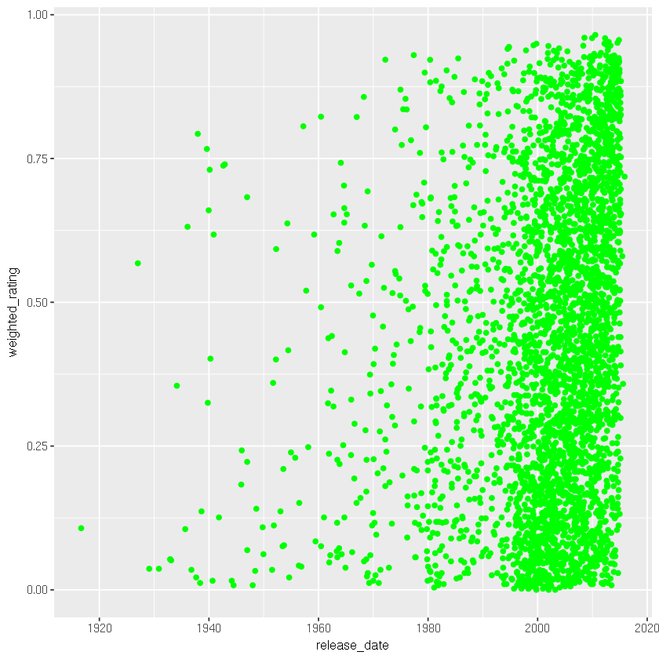

```r
## Here we check the correlation of release date with the popularity of movie
avg_rating%>%
    ggplot(aes(x=release_date, y=weighted_rating))+
    geom_point(color='green')
```

```r
# check correlation coefficient
release=as.numeric(avg_rating$release_date)
cor(release, avg_rating$weighted_rating, use = "na.or.complete")
```

0.19406203147835

since, the correlation coefficient is 0.19 that is we can say release date does not have nuch affect on the popularity of movie. If it’s not release time that affects then it can be budget that determines the popularity.

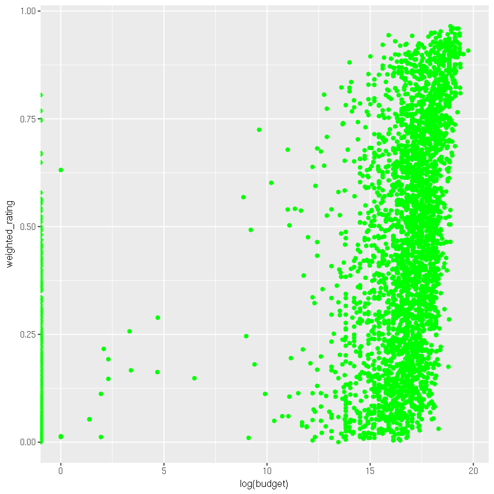

```r
avg_rating%>%
    ggplot(aes(x=log(budget), y=weighted_rating))+
    geom_point(color='green')
```

```r
# check correlation coefficient
cor(avg_rating$budget, avg_rating$weighted_rating, use = "na.or.complete")
```

0.541353001784551

the correlation coefficient is pretty good i.e 0.54 and the scatter plot also shows that more is the budget higher is the popularity giving very less number of points around the lower budget Let's check if there is other factor that has better correlation with popularity. For this let's check for runtime.

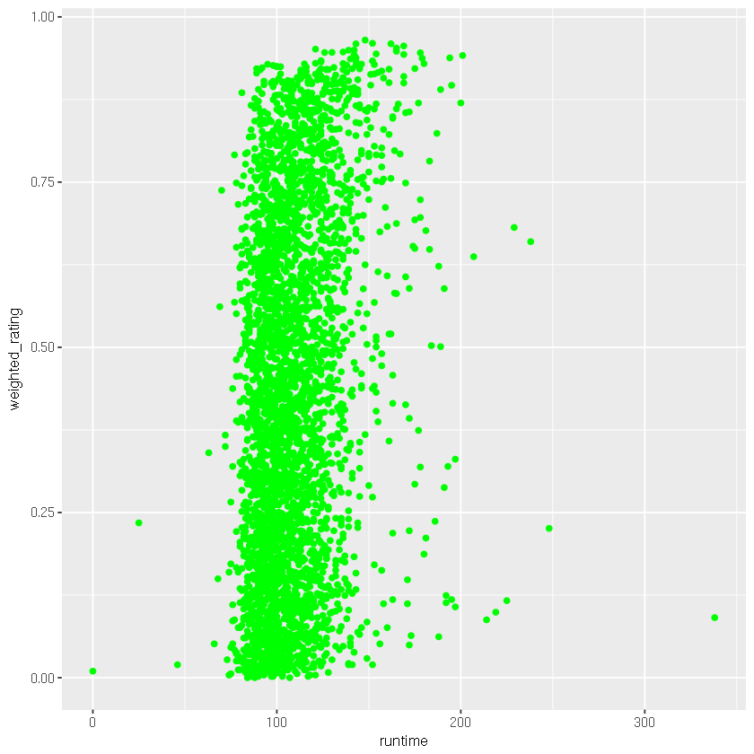

```r
avg_rating%>%
#     filter(runtime > 20)%>%
    ggplot(aes(x=runtime, y=weighted_rating))+
    geom_point(color='green')
```

```r
# check correlation coefficient
cor(avg_rating$runtime, avg_rating$weighted_rating, use = "na.or.complete")
```

0.247666176261122

This coefficient is less than correlation coefficient of budget. Thus, we can say that the popularity of movie in our dataset is affectyed by budget.